# Práctica 2

Cinthya Figueroa, David Vidal y Valeri Suarez

2024-01-16

```r
library(stringr)
library(dplyr)
```

```r
library(ggplot2)
library(readr)
library(rvest)
library(XML)
library(httr)
library(httr2)
library(htmlTable)
library(patchwork)
library(mltools)
library(data.table)
library(car)
```

## Datos Elegantes + Análisis de Datos con Web Scrapping

#### Pregunta 1

Queremos programar un programa de tipo web scrapping con el que podamos obtener una página web, mediante su URL, y poder analizar su contenido HTML con tal de extraer datos e información específica. Nuestro programa ha de ser capaz de cumplir con los siguientes pasos:

1. Descargar la página web de la URL indicada, y almacenarlo en un formato de R apto para ser tratado.

```r
    url <- "https://www.mediawiki.org/wiki/MediaWiki"
    response <- GET(url)
    writeBin(response$content, "wikipedia.html")
```

2. Analizar el contenido de la web, buscando el título de la página (que en HTML se etiqueta como “title”).

```r
    pxml <- htmlParse("wikipedia.html")
    title <- xpathSApply(pxml, "//title", xmlValue)
    cat("El título es:", title, "\n")
```

```
## El título es: MediaWiki
```

3. Analizar el contenido de la web, buscando todos los enlaces (que en HTML se etiquetan como “a”), buscando el texto del enlace, así como la URL.

```r
    enlaces <- xpathSApply(pxml,"//a", function(x) c(URL= xmlGetAttr(x, "href"), Texto = xmlValue(x)))
    val_nulos <- sapply(enlaces, is.null)
    enlaces[val_nulos] <- NA
    V_lista <- unlist (enlaces)
```

4. Generar una tabla con cada enlace encontrado, indicando el texto que acompaña el enlace, y el número de veces que aparece un enlace con ese mismo objetivo.

   Se crea la tabla:

```r
    tabla <- data.frame(URL = enlaces[seq(1, length(enlaces), 2)], Texto = enlaces[seq(2, length(enlaces), 2)])
    tabla_repetidos <- table(tabla$URL)
    tabla$conteo <- tabla_repetidos[match(tabla$URL, names(tabla_repetidos))]
```

[output not shown]

```r
    tabla_repetidos <- table(tabla$URL)
    tabla$conteo <- tabla_repetidos[match(tabla$URL, names(tabla_repetidos))]
```

5. Para cada enlace, seguirlo e indicar si está activo (podemos usar el código de status HTTP al hacer una petición a esa URL).

   Primero se crea una función que busque las URLS que inicien con “https://” y en caso de no tener esa cadena de caracteres pegue la URL del dominio:

```r
burls<- function(url) {
  ifelse(grepl("https://", url), url, paste("https://www.mediawiki.org", url, sep = ''))
                      }
```

```
En la tabla se crea una nueva columna que almacenará los resultados de la funcion creada anteriormente:
```

```r
    tabla$linksr <- sapply (tabla$URL, burls)
```

```
Con las URLS completas se procede a verificar el estado de cada link:
```

```r
    tabla$estado <- sapply( tabla$linksr, function(x) {res <- GET (x)
    Sys.sleep(1)
      status_code (res)} )
```

### Pregunta 2

Elaborad, usando las librerías de gráficos base y qplot (ggplot2), una infografía sobre los datos obtenidos. Tal infografía será una reunión de gráficos donde se muestren los siguientes detalles:

1. Un histograma con la frecuencia de aparición de los enlaces, pero separado por URLs absolutas (con “http…”) y URLs relativas.

Se crea una nueva columna llamada ‘Tipo’ para segun la condición clasificar entre URLs absolutas y relativas

```r
tabla$Tipo <- ifelse(grepl("https:", tabla$URL), "URL Absoluta", "URL Relativa")
```

Con los datos obtenidos se grafica el histograma

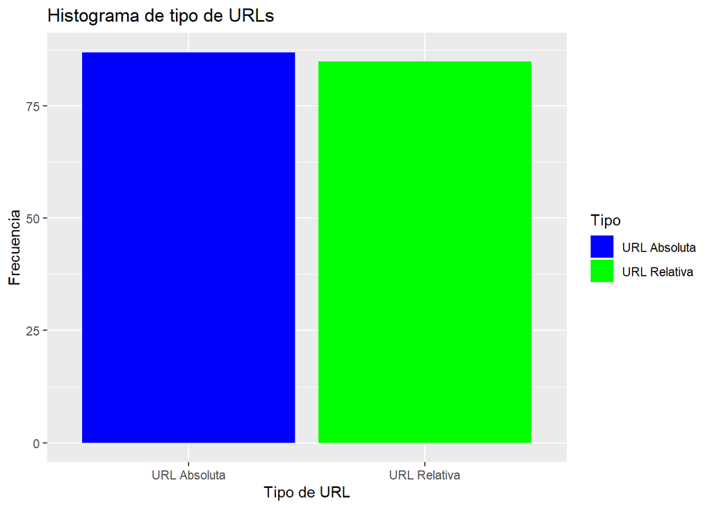

```r
gra1 <- ggplot(data = tabla, aes(x = Tipo, fill = Tipo)) + geom_bar() + labs(title = "Histograma de tipo de URLs", x = "Tipo de URL", y = "Frecuencia") + scale_fill_manual(values = c("URL Absoluta" = "blue", "URL Relativa" = "green"))
gra1
```

2. Un gráfico de barras indicando la suma de enlaces que apuntan a otros dominios o servicios (distinto a https://www.mediawiki.org en el caso de ejemplo) vs. la suma de los otros enlaces.

Creamos una nueva columna llamada ‘TipoEnlace2’ para almacenar la clasificacion entre enlaces a mediawiki y a otras URLs:

```r
tabla$TipoEnlace2 <- ifelse( grepl("https://www.mediawiki.org", tabla$linksr), "MediaWiki", "OTRA URL"
 )
```

Creamos el gráfico de barras:

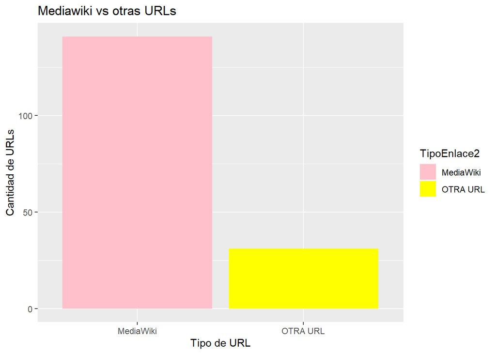

```r
gra2 <- ggplot(data = tabla, aes(x = TipoEnlace2, fill = TipoEnlace2)) +
     geom_bar() +
     labs(title = "Mediawiki vs otras URLs", x = "Tipo de URL", y = "Cantidad de URLs") + scale_fill_manual(values = c("MediaWiki" = "pink", "OTRA URL" = "yellow"))
gra2
```

3. Un gráfico de tarta (pie chart) indicando los porcentajes de Status de nuestro análisis.

El gráfico tarta se lo resolvió de dos maneras, primero obtuvimos el porcentaje de cada valor y luego usando la función ggplot graficamos la tarta, pero la gráfica obtenida no coincide con los valores representados

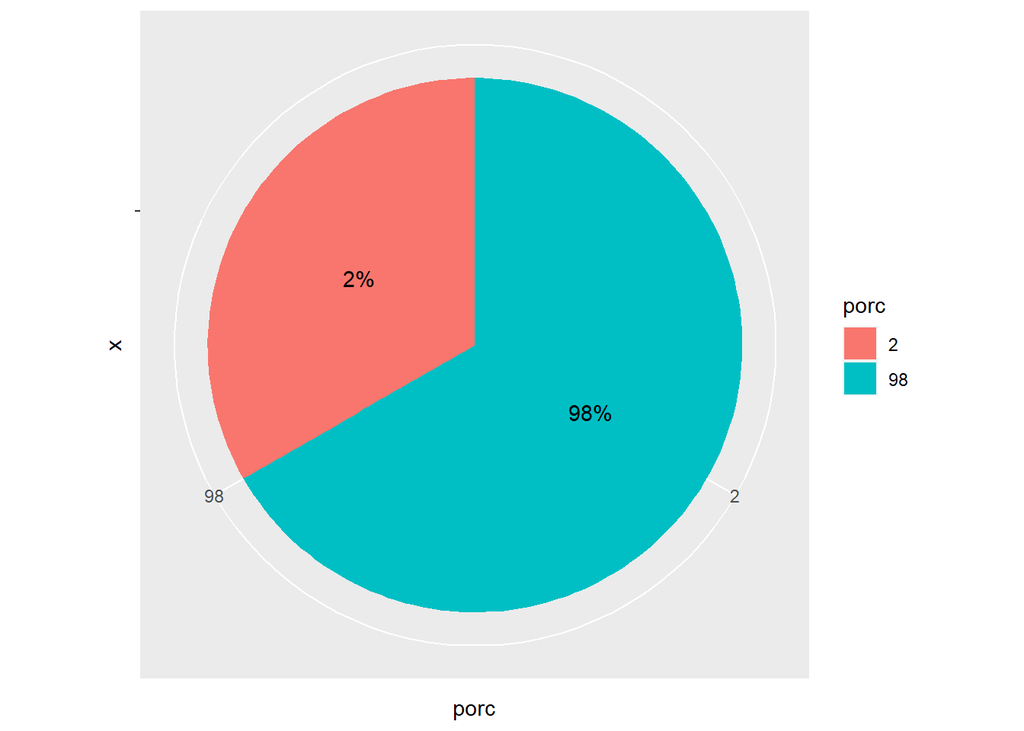

```r
porc<- paste0(round(prop.table(table(tabla$estado)) * 100))

gra3 <-  ggplot(data.frame(porc), aes(x="", y= porc, fill= porc))+ geom_bar(stat = "identity", width = 1) +  coord_polar(theta = "y") + geom_text(aes(label = paste0(porc, "%")), position = position_stack(vjust = 0.5))
gra3
```

La otra solución fue a través de la función pie, en donde el gráfico es más exacto a la porción del porcentaje representado.

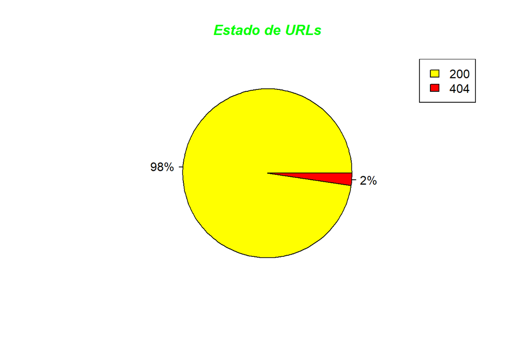

```r
gra4 <- pie(table(tabla$estado), labels = paste0(round(prop.table(table(tabla$estado)) * 100), "%"), col = c("yellow", "red"))

title(main = "Estado de URLs", col.main = "green", font.main = 4)
legend("topright", c("200", "404"), fill = c("yellow", "red"))
```

Se pueden visualizar los graficos juntos:

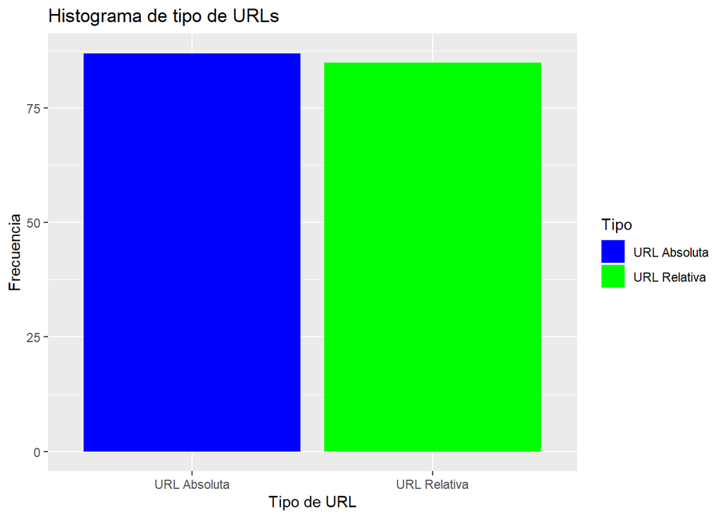

```r
gra1
```

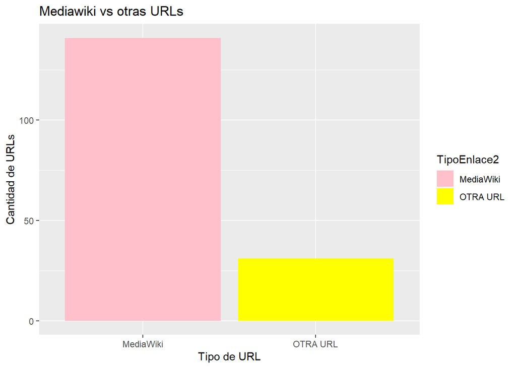

```r
gra2
```

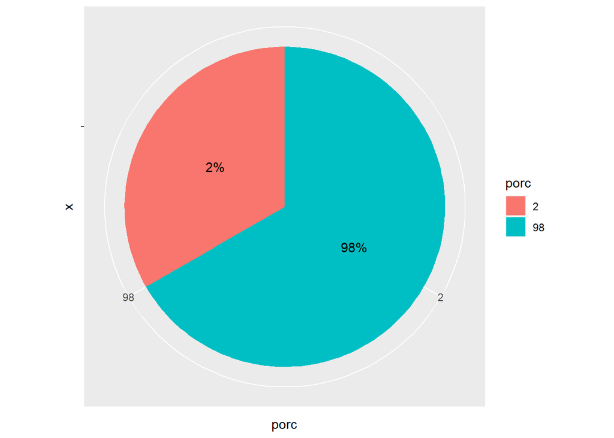

```r
gra3
```

```r
gra4
```

## Análisis de logs de servidor usando R (parte II)

### Obtención y carga de los Datos:

Queremos programar un script con el que podamos hacer una investigación forense sobre un fichero de logs de un servidor de tipo Apache. Los datos del registro del servidor están en el formato estándar e incluyen miles de registros sobre las distintas peticiones gestionadas por el servidor web.

Nuestro programa ha de ser capaz de obtener las respuestas de forma dinámica a las siguientes preguntas utilizando instrucciones de código en R:

1. Descomprimir el fichero comprimido que contiene los registros del servidor, y a partir de los datos extraídos, cargar en data frame los registros con las peticiones servidas. Damos por hecho que el fichero comprimido está guardado en C:con nombre epa_http.zip y descomprimirá el contenido en la misma carpeta c:, teniendo el fichero epa-http.csv en la misma ruta.

```r
# Descomprimos fichero zip ubicado en la ruta C:\temp con nombre epa_http.zip
zipF<- "C:\\temp\\epa_http.zip"
outDir<-"C:\\temp"
unzip(zipF,exdir=outDir)

# Cargamos los datos del fichero epa-http.csv que previametne se ha descomprimido en la ruta C:/temp
epa_http <- read_table ("C:/temp/epa-http.csv", col_names = FALSE, col_types = cols(X7 = col_number()))
```

2. Incluid en el documento un apartado con la descripción de los datos analizados: fuente, tipología, descripción de la información contenida (los diferentes campos) y sus valores.

```r
# Ponemos nombres a las distintas columnas
colnames (epa_http) <- c("IPs", "Timestamp", "Tipo", "URL", "Protocolo", "Código de respuesta", "Bytes")

# Pasamos la columna IPs a tipo factor
epa_http$IPs<- as.factor(epa_http$IPs)

# Limpiamos datos de la columna Tipo quitando una doble comilla que sobra
epa_http$Tipo <- str_replace (epa_http$Tipo, "\"", "")

# Pasamos la columna Tipo a tipo factor
epa_http$Tipo<- as.factor(epa_http$Tipo)

# Pasamos la columna URL a tipo factor
epa_http$URL<- as.factor(epa_http$URL)

# Limpiamos datos de la columna Protocolo quitando una doble comilla que sobra
epa_http$Protocolo <- str_replace (epa_http$Protocolo, "\"", "")

# Pasamos la columna Protocolo a tipo factor
epa_http$Protocolo<- as.factor(epa_http$Protocolo)

# Pasamos la columna Código de respuesta a tipo factor
epa_http$`Código de respuesta` <- as.factor(epa_http$`Código de respuesta`)

# Mostramos resumen de los datos
summary (epa_http)
```

```
##                     IPs         Timestamp           Tipo
##  sandy.rtptok1.epa.gov:  294   Length:47748       GET :46020
##  e659229.boeing.com   :  292   Class :character   HEAD:  106
##  wicdgserv.wic.epa.gov:  266   Mode  :character   POST: 1622
##  keyhole.es.dupont.com:  263
##  dwilson.pr.mcs.net   :  248
##  oea4.r8stw56.epa.gov :  176
##  (Other)              :46209
##                            URL           Protocolo     Código de respuesta
##  /icons/circle_logo_small.gif: 3203   HTTP/0.2:    1   200    :36712
##  /                           : 2382   HTTP/1.0:47747   304    : 5300
##  /logos/small_gopher.gif     : 1851                    302    : 4506
##  /logos/us-flag.gif          : 1817                    404    :  611
##  /logos/small_ftp.gif        : 1815                    403    :  272
##  /icons/book.gif             : 1800                    501    :  272
##  (Other)                     :34880                    (Other):   75
##      Bytes
##  Min.   :      0
##  1st Qu.:    231
##  Median :   1260
##  Mean   :   7352
##  3rd Qu.:   3223
##  Max.   :4816896
##  NA's   :5331
```

Descripción campo IPs: IP de acceso al servidor host Descripción campo Timestamp: Fecha y zona horaria de la petición específica Descripción campo Tipo: Método invocado Descripción campo URL: URL solicitada Descripción campo Protocolo: Protocolo utilizado Descripción campo Código de respuesta: Resultados de código Descripción campo Bytes: Número de bytes transferidos

### Limpieza de los Datos

3. Aprovechando que los datos a analizar son los mismos de la primera práctica, para esta entrega es imprescindible que los datos estén en formato de “datos elegantes”.

```r
# Convertimos columna en formato fecha con hora
epa_http$Timestamp <- as.POSIXct(epa_http$Timestamp, format="[%d:%H:%M:%S]", tz="UTC")
```

### Exploración de Datos

4. Identificar el número único de usuarios que han interactuado directamente con el servidor de forma segregada según si los usuarios han tenido algún tipo de error en las distintas peticiones ofrecidas por el servidor.

```r
# Creamos una variable lógica para los errores (los códigos de respuesta 4xx y 5xx)
epa_http$error <- grepl("^[45]", epa_http$`Código de respuesta`)

# Agrupamos los datos por IP y error y mostramos resumen
epa_http %>%
  group_by(IPs, error) %>%
  summarize(count = n_distinct(Tipo))
```

[output not shown]

```
## # A tibble: 2,512 × 3
## # Groups:   IPs [2,333]
##    IPs                         error count
##    <fct>                       <lgl> <int>
##  1 108.145.internal.radian.com FALSE     1
##  2 128.104.66.114              FALSE     1
##  3 128.120.5.70                FALSE     1
##  4 128.120.68.34               FALSE     1
##  5 128.138.177.19              FALSE     2
##  6 128.138.177.44              FALSE     1
##  7 128.138.177.6               FALSE     2
##  8 128.144.102.56              FALSE     1
##  9 128.150.157.33              FALSE     1
## 10 128.158.53.34               FALSE     2
## # ℹ 2,502 more rows
```

```r
# Pasamos a numérico el código de error para poder hacer comparaciones numérias
epa_http$`Código de respuesta` <- as.numeric(as.character(epa_http$`Código de respuesta`))

# Crear una variable para el tipo de error
epa_http$tipo_error <- case_when(
  epa_http$`Código de respuesta` >= 500 ~ "Error del servidor",
  epa_http$`Código de respuesta` >= 400 ~ "Error del cliente",
  TRUE ~ "Sin error"
)

# Creamos una tabla con la agrupación de la respuesta según si es error del cliente, servidor o si no hay error
tabla_frecuencias <- table(epa_http$tipo_error)

# Creamos una tabla con la frecuencia de los distintos tipos de códigos de respuesta
tabla_tipos_respuesta <- table(epa_http$`Código de respuesta`)

# Mostramos los datos de las dos tablas anteriores
print(tabla_frecuencias)
```

```
##
##  Error del cliente Error del servidor          Sin error
##                889                341              46518
```

```r
print(tabla_tipos_respuesta)
```

```
##
##   200   302   304   400   403   404   500   501
## 36712  4506  5300     6   272   611    69   272
```

```r
# Ahora agrupamos los datos por IP y tipo de error y mostramos resumen
epa_http %>%
  group_by(IPs, tipo_error) %>%
  summarize(count = n_distinct(IPs))
```

[output not shown]

```
## # A tibble: 2,517 × 3
## # Groups:   IPs [2,333]
##    IPs                         tipo_error count
##    <fct>                       <chr>      <int>
##  1 108.145.internal.radian.com Sin error      1
##  2 128.104.66.114              Sin error      1
##  3 128.120.5.70                Sin error      1
##  4 128.120.68.34               Sin error      1
##  5 128.138.177.19              Sin error      1
##  6 128.138.177.44              Sin error      1
##  7 128.138.177.6               Sin error      1
##  8 128.144.102.56              Sin error      1
##  9 128.150.157.33              Sin error      1
## 10 128.158.53.34               Sin error      1
## # ℹ 2,507 more rows
```

Descripción error 400 (Bad Request): Es un error general que indica que tu navegador envía una solicitud al servidor del sitio web y el servidor no puede procesar o reconocer la solicitud. Descripción error 403 (Forbidden): No tienes permiso para ver todo o parte del sitio web por alguna razón. Descripción error 404 (Page Not Found): El sitio web no existe, puede que hahya sido movido o borrado. Descripción error 500 (Internal Server Error): Error interno del servidor. Descripción error 501 (Not Implemented): El servidor no soporta la funcionalidad necesaria para satisfacer la solicitud.

### Análisis de Datos

5. Analizar los distintos tipos de peticiones HTTP (GET, POST, PUT, DELETE) gestionadas por el servidor, identificando la frecuencia de cada una de estas. Repetir el análisis, esta vez filtrando previamente aquellas peticiones correspondientes a recursos ofrecidos de tipo imagen.

```r
# Agrupamos por método HTTP y mostramos resumen de los datos
epa_http %>%
  group_by(Tipo) %>%
  summarize(Total = n())
```

```
## # A tibble: 3 × 2
##   Tipo  Total
##   <fct> <int>
## 1 GET   46020
## 2 HEAD    106
## 3 POST   1622
```

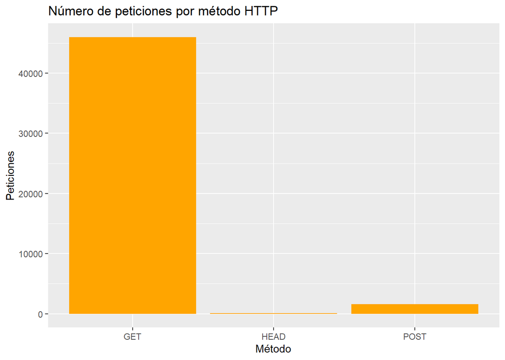

```r
# Creamos un gráfico de barras del número de peticiones por método HTTP
ggplot(epa_http, aes(x = Tipo)) +
  geom_bar(fill="orange") +
  labs(title = "Número de peticiones por método HTTP", x = "Método", y = "Peticiones")
```

```r
# Repetimos análisis esta vez filtrando previamente por peticiones de imágenes
epa_http$imagen <- grepl("\\.(jpg|png|gif|bmp|svg)$", epa_http$URL, ignore.case = TRUE)

# Filtramos el log para que muestre solo las filas que tienen el campo imagen que creamos a TRUE
epa_http_imagenes <- filter(epa_http, imagen == TRUE)

# Agrupamos por método HTTP y mostramos resumen de los datos filtrados por peticiones de imágenes
epa_http_imagenes %>%
  group_by(Tipo) %>%
  summarize(Total = n())
```

```
## # A tibble: 3 × 2
##   Tipo  Total
##   <fct> <int>
## 1 GET   22179
## 2 HEAD     56
## 3 POST    206
```

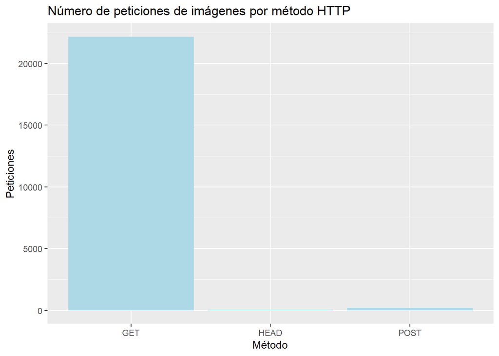

```r
# Creamos un gráfico de barras del número de peticiones por método HTTP filtradas por peticiones de imágenes
ggplot(epa_http_imagenes, aes(x = Tipo)) +
  geom_bar(fill="lightblue") +
  labs(title = "Número de peticiones de imágenes por método HTTP", x = "Método", y = "Peticiones")
```